# Load Data

```python
import pandas as pd
df_Info_data = pd.read_csv('https://storage.googleapis.com/datalynn-datasets/interview-challenge/technology/Oracle_Data_Integrator/OracleInfoData.csv')
df_Info_data.head()
```

|  | user_id | session_id | timestamp | system_load | queries | db_size | errors | response_time | integration_tool | user_type |
| --- | --- | --- | --- | --- | --- | --- | --- | --- | --- | --- |
| 0 | U103 | S1 | 2022-01-01 00:53:00 | 51.830767 | 6 | 38.931472 | 0 | 85.047255 | GoldenGate | general user |
| 1 | U271 | S2 | 2022-01-01 08:03:00 | 36.442631 | 3 | 49.069598 | 0 | 86.934273 | GoldenGate | general user |
| 2 | U107 | S3 | 2022-01-01 20:24:00 | 55.211235 | 2 | 46.926947 | 0 | 99.405651 | ODI | general user |
| 3 | U72 | S4 | 2022-01-03 00:22:00 | 42.005864 | 10 | 42.608346 | 0 | 128.697876 | GoldenGate | general user |
| 4 | U189 | S5 | 2022-01-03 18:46:00 | 76.545217 | 6 | 51.174172 | 0 | 110.759460 | ODI | developer |

## Question 1

**Data Manipulation & Cleaning**:

During a session analysis, you notice there are some records with extreme `response_time` values, likely due to system glitches. Identify sessions where the `response_time` seems like an outlier, and propose a strategy to handle them.

**Outlier Detection Using IQR**

```python
import pandas as pd
import numpy as np
from scipy import stats

df = df_Info_data.copy()

Q1 = df['response_time'].quantile(0.25)
Q3 = df['response_time'].quantile(0.75)
IQR = Q3 - Q1

# Filtering Values between Q1-1.5IQR and Q3+1.5IQR
outliers = df[(df['response_time'] < (Q1 - 1.5 * IQR)) | (df['response_time'] > (Q3 + 1.5 * IQR))]
outliers
```

|  | user_id | session_id | timestamp | system_load | queries | db_size | errors | response_time | integration_tool | user_type |
| --- | --- | --- | --- | --- | --- | --- | --- | --- | --- | --- |
| 24 | U170 | S25 | 2022-01-12 20:26:00 | 25.446030 | 5 | 55.496804 | 0 | 69.790358 | GoldenGate | developer |
| 43 | U264 | S44 | 2022-01-18 23:46:00 | 29.338211 | 2 | 57.501682 | 0 | 61.803334 | GoldenGate | developer |
| 118 | U237 | S119 | 2022-02-10 20:58:00 | 57.633251 | 5 | 68.405157 | 1 | 162.839918 | GoldenGate | developer |
| 157 | U233 | S158 | 2022-02-22 04:04:00 | 18.758673 | 2 | 69.352038 | 0 | 63.800808 | GoldenGate | general user |
| 184 | U184 | S185 | 2022-03-04 03:42:00 | 71.145562 | 8 | 70.960804 | 1 | 172.495721 | GoldenGate | general user |
| 208 | U298 | S209 | 2022-03-13 00:18:00 | 52.717856 | 2 | 83.715526 | 0 | 68.263055 | ODI | general user |
| 376 | U247 | S377 | 2022-05-11 01:54:00 | 22.528800 | 4 | 98.618877 | 0 | 74.018609 | ODI | admin |
| 386 | U94 | S387 | 2022-05-15 09:48:00 | 17.096431 | 4 | 116.373227 | 0 | 70.103345 | ODI | general user |
| 436 | U105 | S437 | 2022-05-27 22:58:00 | 47.219847 | 9 | 125.026645 | 1 | 181.996404 | GoldenGate | general user |
| 707 | U73 | S708 | 2022-09-12 04:01:00 | 33.407218 | 2 | 149.996632 | 1 | 169.306527 | ODI | admin |
| 760 | U68 | S761 | 2022-10-06 12:03:00 | 74.657252 | 14 | 165.517701 | 0 | 174.158855 | GoldenGate | general user |
| 839 | U38 | S840 | 2022-11-03 05:39:00 | 61.496263 | 7 | 166.576641 | 1 | 186.070453 | GoldenGate | general user |
| 883 | U67 | S884 | 2022-11-24 14:20:00 | 63.683401 | 11 | 173.810754 | 0 | 166.859567 | ODI | general user |
| 923 | U148 | S924 | 2022-12-04 20:31:00 | 58.946837 | 6 | 180.912042 | 1 | 176.276611 | GoldenGate | general user |
| 963 | U25 | S964 | 2022-12-17 06:06:00 | 76.509290 | 5 | 187.862826 | 0 | 170.045912 | ODI | general user |

**Strategies to Handle Outliers**

- Remove outliers: If you're certain that these outliers are due to glitches or errors, they can be removed to prevent them from affecting the model.
- Imputation: Replace the outlier values with median or mean values. Median is more robust to outliers than mean.
- Capping: Replace outlier values by a certain threshold, e.g., values above a certain range can be set to the value at the 95th percentile.

## Question 2

**Probability and Statistics**:

Given the data collected over the past year, determine if there's a statistically significant difference in `response_time` when using Oracle Data Integrator (ODI) compared to Oracle GoldenGate.

```python
from scipy import stats

# Separate the data for each integration tool:
odi_times = df[df['integration_tool'] == 'ODI']['response_time']
goldengate_times = df[df['integration_tool'] == 'GoldenGate']['response_time']

# Conduct the two-sample t-test:
t_stat, p_value = stats.ttest_ind(odi_times, goldengate_times, equal_var=True)

# Set the significance level aplha as 0.05
# If p-value > aplha, we determine that there is no statistically significant difference, vice versa.
alpha = 0.05
if p_value < alpha:
  print("The p-value we get is: " + str(p_value))
  print("There is a statistically significant difference in response_time between ODI and GoldenGate.")
else:
  print("The p-value we get is: " + str(p_value))
  print("There is no statistically significant difference in response_time between ODI and GoldenGate.")
```

```
The p-value we get is: 0.7978748701495455
There is no statistically significant difference in response_time between ODI and GoldenGate.
```

## Question 3

**Machine Learning & Modeling**:

Scenario: The response time is crucial for maintaining a high-quality user experience. Using the available data, create a model to predict `response_time` based on the input features. Clearly specify the feature importance once the model is trained.

**Target Variable**: `response_time`

```python
import pandas as pd
from sklearn.preprocessing import StandardScaler, OneHotEncoder
from sklearn.compose import ColumnTransformer
from sklearn.pipeline import Pipeline
from sklearn.model_selection import train_test_split
from sklearn.ensemble import RandomForestRegressor
from sklearn.linear_model import LinearRegression
from sklearn.metrics import mean_squared_error

# Drop identifiers as they don't contribute to the model's predictive power
df2 = df.copy().drop(columns=['user_id', 'session_id', 'timestamp'])

# Separate features and target
X = df2.drop('response_time', axis=1)
y = df2['response_time']

# Create a preprocessor
numeric_features = ['system_load', 'queries', 'db_size', 'errors']
numeric_transformer = StandardScaler()

categorical_features = ['integration_tool', 'user_type']
categorical_transformer = OneHotEncoder(drop='first')

preprocessor = ColumnTransformer(
    transformers=[
        ('num', numeric_transformer, numeric_features),
        ('cat', categorical_transformer, categorical_features)
    ]
)

# Split the train and test sets
X_train, X_test, y_train, y_test = train_test_split(X, y, test_size=0.2, random_state=42)

# Define the model
model = Pipeline([
    ('preprocessor', preprocessor),
    ('regressor', RandomForestRegressor(n_estimators=100, random_state=10))
])

# Train the model
model.fit(X_train, y_train)

# Make predictions
y_pred = model.predict(X_test)

# Measure performance
rmse = np.sqrt(mean_squared_error(y_test, y_pred))
print(f"Root Mean Squared Error: {rmse}")
```

```
Root Mean Squared Error: 12.020326165532795
```

**Feature Importance**

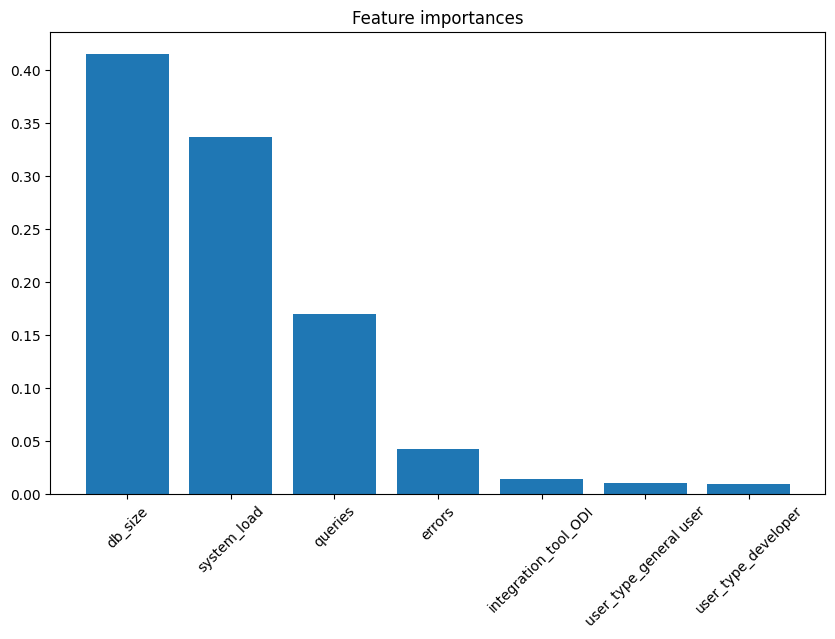

```python
import matplotlib.pyplot as plt

# Extract feature importances from the trained model
importances = model.named_steps['regressor'].feature_importances_

# For the actual feature names after one-hot encoding
columns_after_encoding = (model.named_steps['preprocessor']
                          .named_transformers_['cat']
                          .get_feature_names_out(input_features=categorical_features))

all_features = np.concatenate([numeric_features, columns_after_encoding])

# Sort feature importances in descending order
indices = np.argsort(importances)[::-1]

# Visualize feature importances
plt.figure(figsize=(10, 6))
plt.title("Feature importances")
plt.bar(range(len(all_features)), importances[indices])
plt.xticks(range(len(all_features)), all_features[indices], rotation=45)
plt.show()
```

## Question 4

**Business Context**:

Among the user types (`admin`, `developer`, `general user`), identify which group encounters the most errors during their sessions. Further, determine if this has a significant impact on `response_time`.

```python
# Group by user_type and sum the errors
error_counts = df.groupby('user_type')['errors'].sum()

# Display the user type with the most errors
print(error_counts.sort_values(ascending=False))

# Group data by user_type
groups = [df['response_time'][df['user_type'] == user_type] for user_type in ["admin", "developer", "general user"]]

# Perform ANOVA
f_val, p_val = stats.f_oneway(*groups)

print(f"F-Value: {f_val}")
print(f"P-Value: {p_val}")
```

```
user_type
general user    4
admin           2
developer       1
Name: errors, dtype: int64
F-Value: 0.6520229986820892
P-Value: 0.5212127574747576
```

- P-Value of 0.5212 is well above the 0.05 threshold. This means that we fail to reject the null hypothesis, suggesting that there isn't a statistically significant difference in `response_time` among the user types.